# R_Circlize包_弦图

Mr Li

2018年11月5日

[参考来源](https://jokergoo.github.io/circlize_book/book/the-chorddiagram-function.html)

# 1 par参数：

- lty: line type. 可以是数字或者字符,  
  (0 = “blank”, 1 = “solid” (default), 2 = “dashed”, 3 = “dotted”, 4 = “dotdash”, 5 = “longdash”, 6 = “twodash”)
- lwd: line width. 默认是 1, 设置线宽的放大倍数.
- cex: 设置文字和符号相对于默认值的大小, 为一个比例数值. 当使用 mfrow 或 mfcol 也会改变该值.
- mai: 以 inch 为单位的图像边距, c(bottom, left, top, right).
- mar: 以行数来表示图像边距, c(bottom, left, top, right), 默认是 c(5, 4, 4, 2) + 0.1.
- mfcol, mfrow: 调整图形输出设备中子图排列的向量, c(nrow, ncol), mfcol 让子图按照列优先排列, 相应的, mfrow 让子图按照行优先排列.当设置 mfcol mfrow 后, cex 和 mex 的基本单位都相应减小.  
  [参考来源及其它参数](https://zhuanlan.zhihu.com/p/21394945)

# 2 和弦图

## 2.1 和弦图简介

和弦图长什么样子：  
[和弦图在线](http://circos.ca/intro/tabular_visualization/)  
和弦图即可以反映2类变量之间的相互作用关系，也可以反映相互作用强度，这是其它图比不了的  
和弦图的弦link的宽度代表所连接的两个对象的相互作用强弱，link越宽，则相互作用越强  
和弦图常用于绘制国家之间的贸易往来量，城市之间的航班往来量，还有细胞和基因数据可视化(这个领域不了解)

### 2.1.1 邻接表(和弦图数据源)

邻接表强调2类对象之间的相互作用强弱，分为邻接矩阵(adjacency matrix)和邻接列表(adjacency list)  
* 邻接矩阵为表示矩阵格式，邻接矩阵的元素映射到弦link的宽度，表示所在行名称和列名称的相互作用强弱  
* 邻接列表通常前2列分别为2类对象，第3列映射到弦link的宽度，表示前2列对应行的元素相互作用强弱  
circlize内置的和弦图绘制函数`chordDiagram()`对这2种邻接表都支持，但对于后续参数修改，使用邻接列表更方便  
**邻接表：**

```r
library(circlize)

# 编一个邻接矩阵
mat <- matrix(1:9, 3)  # 第1列不是id列，通过行命名替代
rownames(mat) <- letters[1:3]
colnames(mat) <- LETTERS[1:3]
mat

# 编一个邻接列表
df <- data.frame(from = letters[1:3], to = LETTERS[1:3], value = 1:3)
df
```

```
##   A B C
## a 1 4 7
## b 2 5 8
## c 3 6 9
```

| from | to | value |
| --- | --- | --- |
| a | A | 1 |
| b | B | 2 |
| c | C | 3 |

**可以使用内置函数`generateRandomBed()`产生随机基因类数据：**  
语法： `generateRandomBed(nr = 10000, nc = 1, fun = function(k) rnorm(k, 0, 0.5), species = NULL)` 参数解释：  
* nr 表示指定产生数据行数 * nc 表示指定产生数据列数, 数据值的列  
* fun 表示指定参数随机数的方法  
* species 表示种类，传递给`read.cytoband`

```r
library(circlize)

set.seed(999)
bed = generateRandomBed()  # 默认参数
head(bed)

bed = generateRandomBed(nr = 200, nc = 4)
nrow(bed)

bed = generateRandomBed(nc = 2, fun = function(k) sample(letters, k, replace = TRUE))  # 默认产生1000行数据
head(bed)
```

|  | chr | start | end | value1 |
| --- | --- | --- | --- | --- |
| 1 | chr1 | 39485 | 159163 | -0.1887635 |
| 2 | chr1 | 897195 | 1041959 | -0.2435220 |
| 3 | chr1 | 1161957 | 1177159 | 0.3749953 |
| 4 | chr1 | 1201513 | 1481406 | -0.2600839 |
| 5 | chr1 | 1487402 | 1531773 | -0.4633990 |
| 6 | chr1 | 1769949 | 2736215 | -0.8159909 |

```
## [1] 205
```

|  | chr | start | end | value1 | value2 |
| --- | --- | --- | --- | --- | --- |
| 1 | chr1 | 98740 | 566688 | e | e |
| 2 | chr1 | 769960 | 887938 | b | q |
| 3 | chr1 | 906851 | 933021 | u | o |
| 4 | chr1 | 1241911 | 1243537 | k | f |
| 5 | chr1 | 1385344 | 1410947 | v | x |
| 6 | chr1 | 1498302 | 1585389 | u | v |

## 2.2 初步绘图

输入邻接表数据，默认参数，自动绘图，  
**构造数据**

```r
library(circlize)

# 构造一个邻接矩阵
set.seed(999)
mat <- matrix(sample(18, 18), 3, 6) # 3行6列的矩阵
rownames(mat) <- paste0("S", 1:3) # 生成行名
colnames(mat) <- paste0("E", 1:6) # 生成列名

# 构造一个邻接列表
df <- data.frame(from = rep(rownames(mat), times = ncol(mat)), # 第1列对象
                 to = rep(colnames(mat), each = nrow(mat)), # 第2列对象
                 value = as.vector(mat),  # 第3列前2列对象相互作用强度
                 stringsAsFactors = FALSE)
df
```

| from | to | value |
| --- | --- | --- |
| S1 | E1 | 8 |
| S2 | E1 | 10 |
| S3 | E1 | 2 |
| S1 | E2 | 13 |
| S2 | E2 | 12 |
| S3 | E2 | 16 |
| S1 | E3 | 18 |
| S2 | E3 | 1 |
| S3 | E3 | 4 |
| S1 | E4 | 6 |

[output cut: 8 more lines]

**绘图**

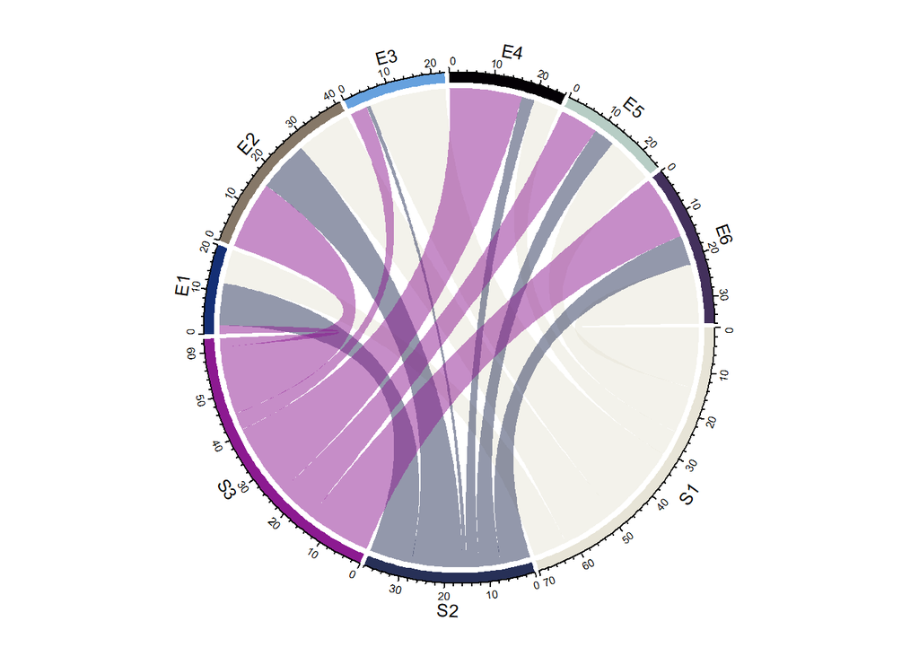

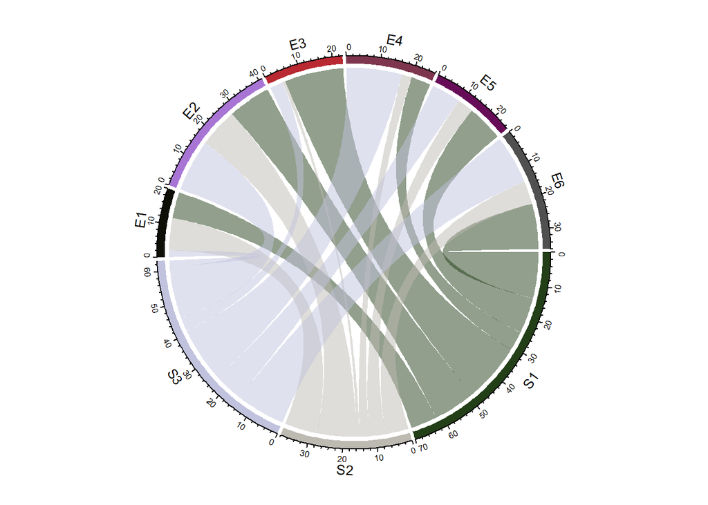

```r
library(circlize)

# 使用邻接矩阵
chordDiagram(mat)
circos.clear()  # 结束绘图，否则会继续叠加图层

# 使用邻接列表
chordDiagram(df)
circos.clear()
```

# 3 参数调整

调整了参数，绘图结束后，使用`circos.clear()`重置参数，使返回到默认状态  
参数分为2大类：  
* 第1类为`circos.par()`内置参数  
* 第2类为`chordDiagram()`内置参数

## 3.1 `circos.par`内置参数

| 分类 | 参数 | 描述 |
| --- | --- | --- |
| sectors间隙 | `gap.after` | 调整外围sectors之间的间隙，用数字向量进行指定 |
| sectors旋转方向 | `clock.wise` | 为逻辑值，设置外围sectors的旋转方向 |
| sectors起点位置 | `start.degree` | 为-360到360的数字，调整第一个sector的位置，与旋转方向有关 |

### 3.1.1 gap 间隙调整

sectors之间的间隙可以用`gap.after =`调整  
指定间隙的数字向量长度应该与sectors数量一致

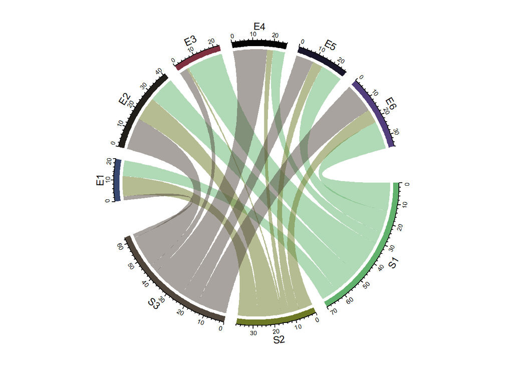

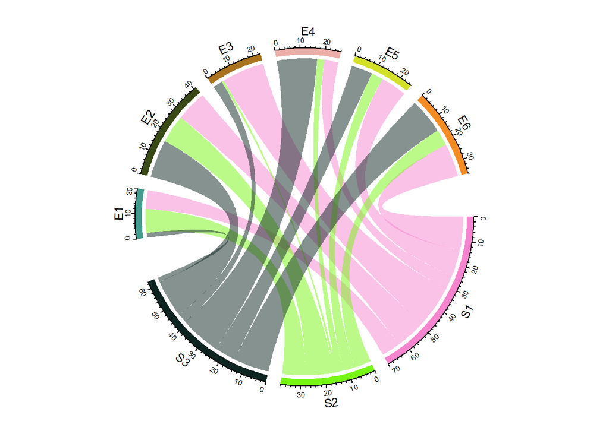

```r
library(circlize)

# 使用邻接矩阵时
circos.par(gap.after = c(rep(5, nrow(mat)-1),  # 2个5，表示3个行名之间的间隙分别为5个单位
                         15,                   # 表示行名与列名之间的间隙，为15个单位
                         rep(5, ncol(mat)-1),  # 5个5，表示6个列名之间的间隙分别为5个单位
                         15))                  # 表示列名与行名之间的间隙，为15个单位
chordDiagram(mat)
circos.clear() # 返回默认设置

# 使用邻接列表时
circos.par(gap.after = c(rep(5, length(unique(df[[1]]))-1), # 表示第1列元素之间的间隙为5个单位
                         15,                                # 表示第1列与第2列之间的间隙为15个单位
                         rep(5, length(unique(df[[2]]))-1), # 表示第2列元素之间的间隙为5个单位
                         15))                               # 表示第2列与第1列之间的间隙为15个单位
chordDiagram(df)
circos.clear()
```

### 3.1.2 sector起点位置及旋转方向调整

sector默认为3点钟顺时针方向， * `circos.par(start.degree = )`可以调整起点位置，起点位置还与旋转方向有关  
* `circos.par(clock.wise = FALSE/TRUE)` 可以调整旋转方向

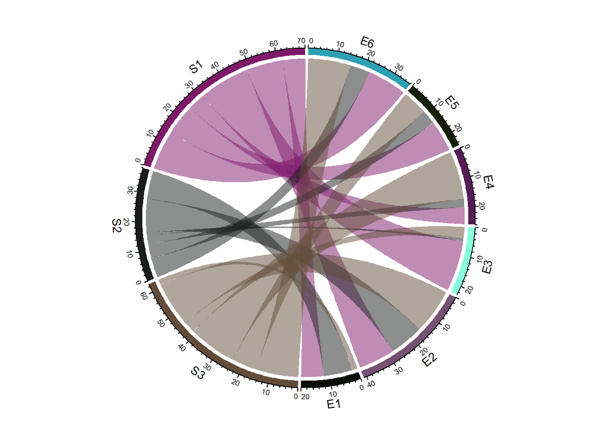

```r
library(circlize)

circos.par(start.degree = 90, clock.wise = FALSE)  # 逆时针旋转，起点位置在逆时针90度方向，即12点针方向
chordDiagram(mat)
circos.clear()
```

## 3.2 `chordDiagram`内置参数

`chordDiagram()`内置参数很多，分类及作用如下：

| 分类 | 参数 | 描述 |
| --- | --- | --- |
| sectors顺序 | `order` | 调整外围sectors排列顺序，用字符串向量指定，其长度与sectors数量一致 |
| sectors颜色 | `grid.col` | 调整外围sectors颜色，颜色向量指定，通常使用名称属性进行匹配，默认顺序匹配 |
| link颜色 | `col` | 用颜色矩阵或颜色向量指定，对于邻接矩阵和邻接列表不一样 |
| link透明度 | `transparency` | 用0(不透明)到1(透明)的数字指定，如果要设置不同的透明度，则用法与颜色指定类似 |
| link边线宽 | `link.lwd` | 用数字指定link弦边缘线宽度 |
| link边线型 | `link.lty` | 用数字指定link弦边缘线的线型，与par参数一致 |
| link边线颜色 | `link.border` | 指定link弦边缘线的颜色 |
| link弦可见 | `link.visible` | 指定要显示的弦，用逻辑向量或矩阵指定，只显示逻辑值为正的弦 |
| sectors内的顺序 | `link.decreasing` | 为逻辑值，表示指定link在sector内的顺序，需要先指定`link.sort = TRUE` |
| sectors外顺序 | `link.rank` | 指定link在各个sector之间的顺序，用数字向量或矩阵指定，值大的后添加在表层 |
| 自我连接 | `self.link` | 指定自我连接的类型，=1 或 =2 |
| 对称矩阵 | `symmetric` | 为逻辑值，`symmetric = TRUE`表示只画邻接矩阵下三角部分，不包括对角线 |
| link方向 | `directional` | =1或 =-1,设置方向后，link终点高度将缩短，可以调节缩短量 |
| link箭头 | `direction.type` | 指定方向类型: `"arrows"`，`c("arrows", "diffHeight")`，`"big.arrow"`大箭头 |
| link高度 | `diffHeight` | 指定link终点缩短量，可以为负数,必须先在`direction.type`中设定`diffHeight` |
| 窄弦丢弃 | `reduce` | 从0到1的数字，表示link宽度小于弦总宽度百分比的link将不予显示,`circos.info()`可查看 |
| 轨道显示 | `annotationTrack` | 表示指定要显示的轨道,`NULL`隐藏，`c("name", "grid", "axis")`标签，网格和刻度 |

### 3.2.1 外围sectors的顺序

- 对于邻接矩阵，外围sector的顺序与`union(rownames(mat), colnames(mat))`一致，默认从3点钟方向顺时针旋转
- 对于邻接列表，外围sector的顺序与`union(df[[1]], df[[2]])`一致
- `order`参数调整外围sector的顺序，当然指定字符串向量的长度应与sectors的数量一致  
  如图所示：

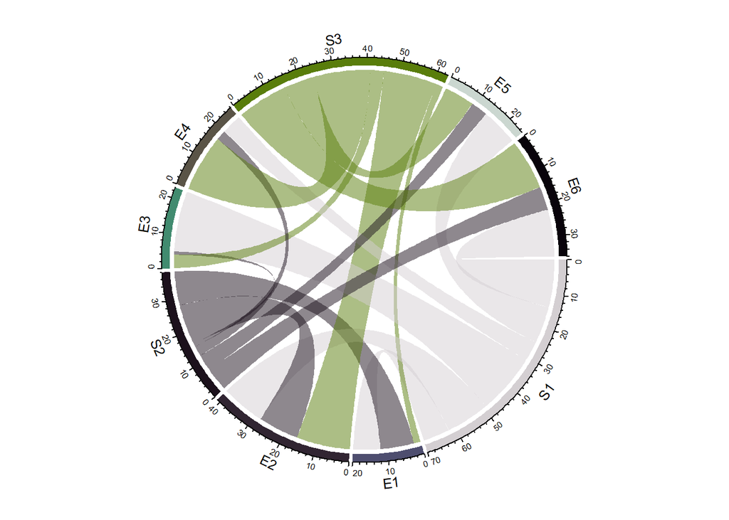

```r
library(circlize)

chordDiagram(mat, order = c("S1", "E1", "E2", "S2", "E3", "E4", "S3", "E5",
    "E6"))  # 使用order参数调整顺序，默认3点钟顺时针方向
circos.clear()
```

### 3.2.2 颜色调整

通常外围sector分为2类，第1类代表邻接矩阵的行名或邻接列表的第一列，第2类代表邻接矩阵的列名和邻接列表的第2列， 连接弦link就是将2类sectors连接起来， **默认连接弦link的颜色与第1类对象的颜色一致**，  
改变外围sector中第1类对象的颜色，连接弦的颜色也会随之改变  
* 外围sector的颜色可以用`chordDiagram(grid.col= )`参数调整，  
指定的颜色向量最好有一个名称属性，该名称属性与secters名称一样，这样才能一一匹配，否则没有名称属性则按顺序匹配  
* 连接弦link的透明度可以用transparency参数调整，从0(完全不透明)到1(完全透明)，默认透明度为0.5  
* 连接弦link的参数可以用col参数调整，需要指定**颜色矩阵**(数据为邻接矩阵) 或**颜色向量**(数据为邻接列表)  
可以用函数`rand_color()`产生随机颜色矩阵，可以在里面设置透明度参数，再指定透明度会被忽略  
当相互作用relation为连续变量时，可以通过`colorRamp2()`产生连续的颜色向量，col参数也支持  
* 当数据是连接矩阵时，可以不提供颜色矩阵，link颜色指定还可以用颜色向量指定，使用参数`row.col`或`column.col`指定  
仅仅提供与行名或列名长度相同的颜色向量，颜色向量可以用颜色名称，hex色值，甚至数字表示  
**调整sectors颜色和link透明度**

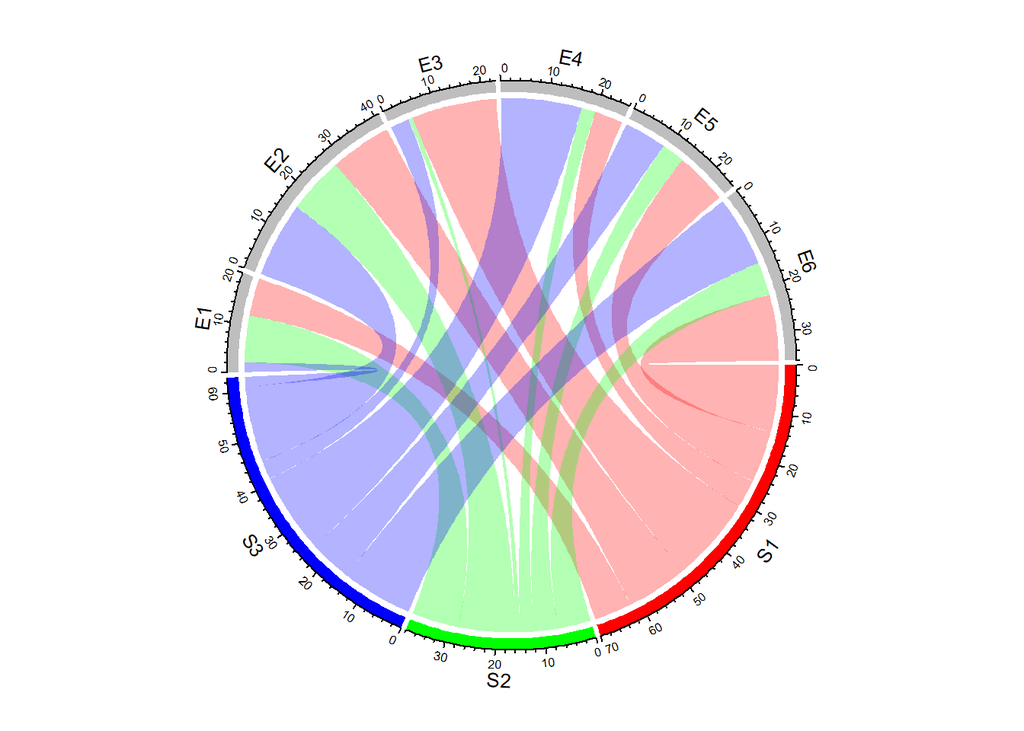

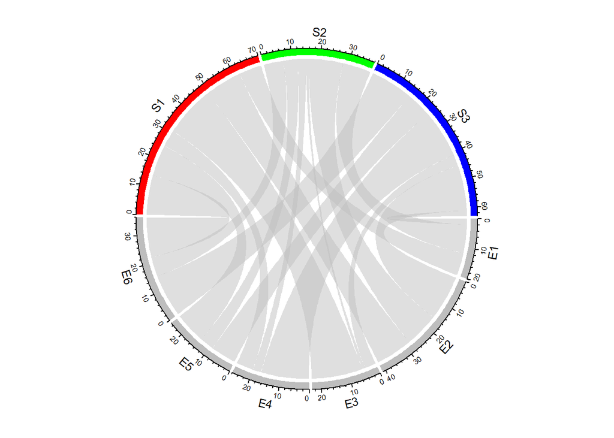

```r
library(circlize)

grid_col <- c(S1 = "red", S2 = "green", S3 = "blue", E1 = "grey", E2 = "grey",
    E3 = "grey", E4 = "grey", E5 = "grey", E6 = "grey")  # 构建颜色向量，指定名称属性，则按名称匹配
chordDiagram(mat, grid.col = grid_col, transparency = 0.7)  # 调整外围sector颜色，增加透明度
chordDiagram(t(mat), grid.col = grid_col)  # 按名称匹配，则link颜色与mat矩阵的列名一致，全变为灰色
```

### 3.2.3 调整link颜色及透明度

`colorRamp2(breaks, colors, transparency = 0, space = "LAB")` 离散色板连续化，space表示色彩空间

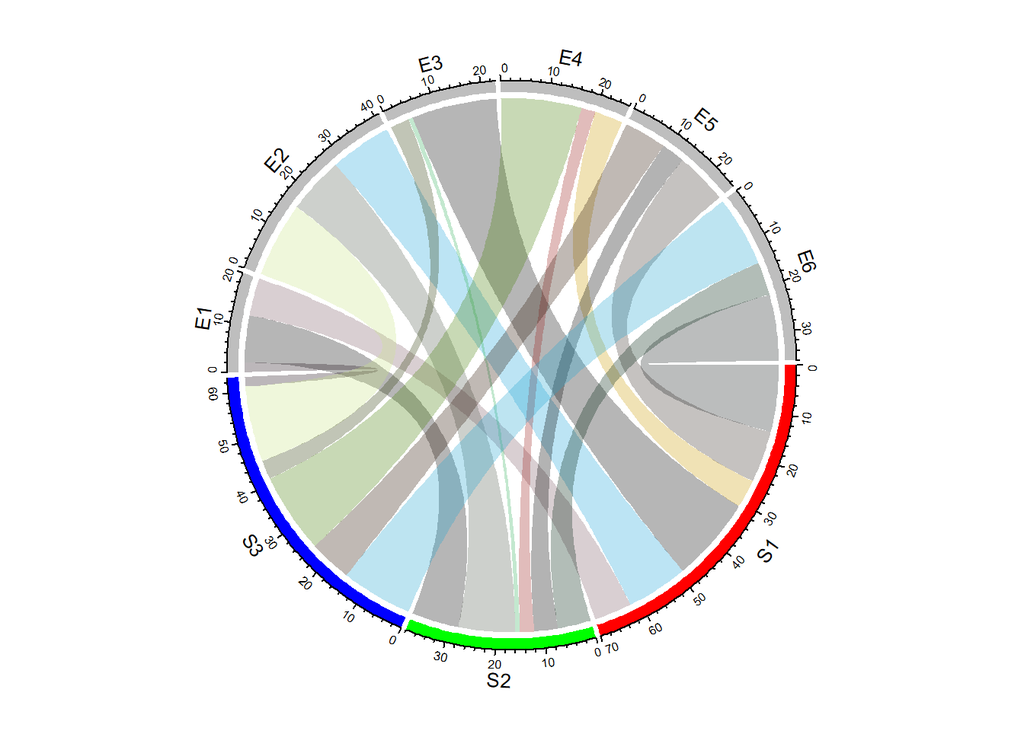

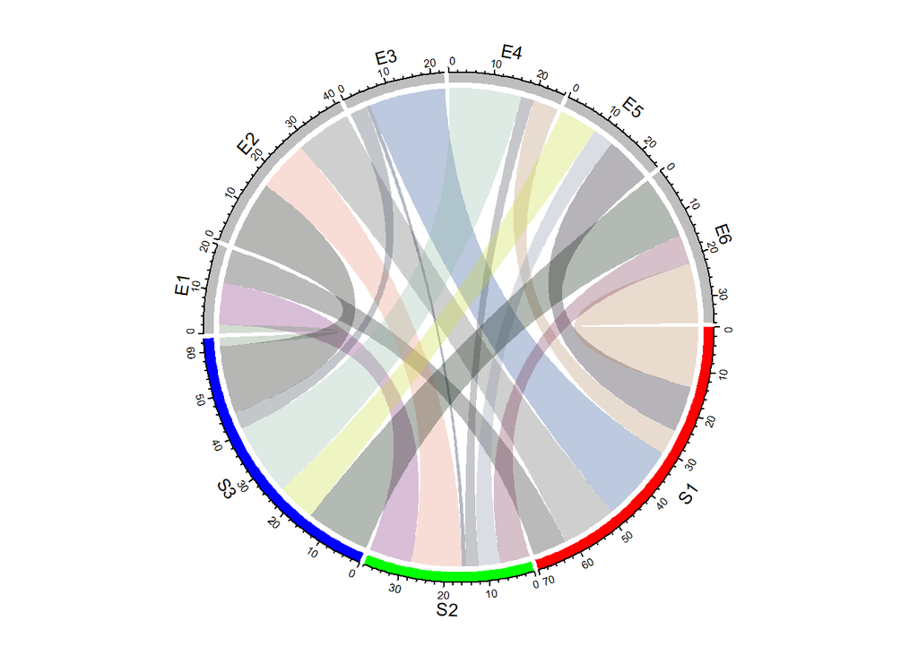

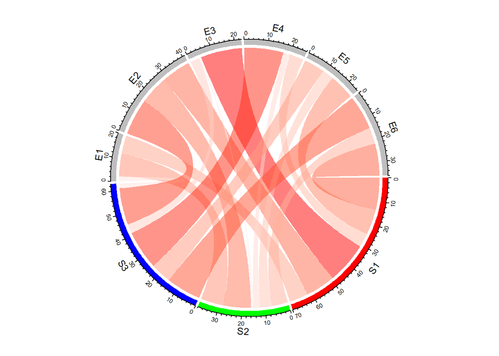

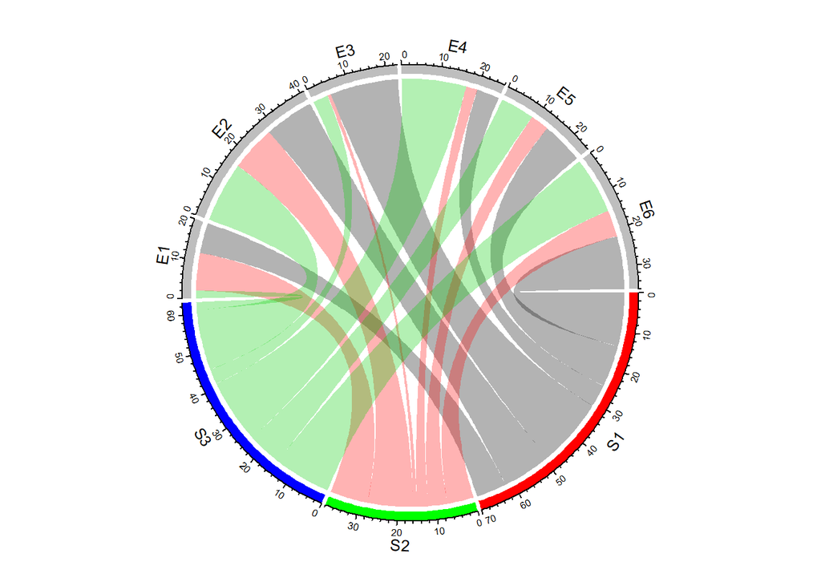

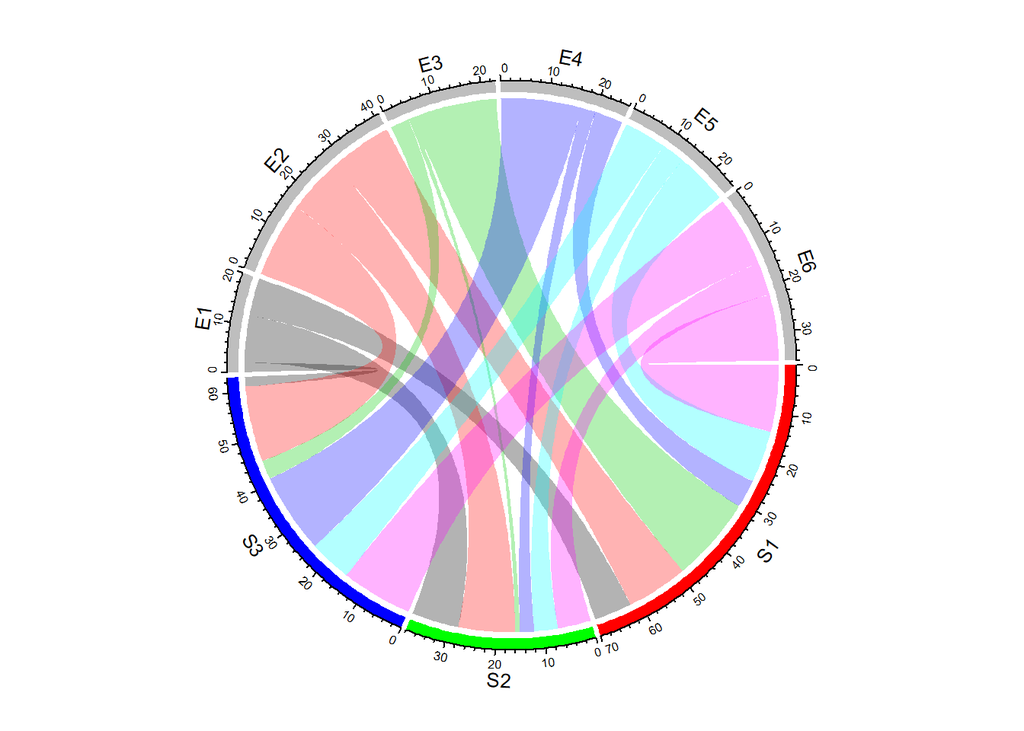

```r
library(circlize)

# 数据是邻接矩阵
col_mat <- rand_color(length(mat), transparency = 0.7)  # 产生随机颜色矩阵，并指定透明度
dim(col_mat) <- dim(mat)  # 以确保col_mat是一个矩阵
chordDiagram(mat, grid.col = grid_col, col = col_mat)  # 设置link颜色，
circos.clear()

# 数据是邻接列表
cols <- rand_color(nrow(df), transparency = 0.7)
chordDiagram(df, grid.col = grid_col, col = cols)
circos.clear()

# link为连续变量
col_fun <- colorRamp2(range(mat), c("#FFEEEE", "#FF0000"), transparency = 0.5)  # 产生连续色块并指定透明度
chordDiagram(mat, grid.col = grid_col, col = col_fun)
circos.clear()

# 用数字指定link颜色
chordDiagram(mat, grid.col = grid_col, row.col = 1:3, transparency = 0.7)  # 用数字向量指定颜色，向量长度与连接矩阵的行数相同
chordDiagram(mat, grid.col = grid_col, column.col = 1:6, transparency = 0.7)  # 用数字向量指定颜色，向量长度与连接矩阵的列数相同
circos.clear()
```

### 3.2.4 link边线宽，边线型，边线颜色

- link,lwd 参数调整link边缘线宽度
- link.lty 参数调整link边缘线线型
- link.border 参数调整link边缘线的颜色
- 当数据是邻接矩阵时，这3个参数均可以用长度为1的向量指定，或矩阵

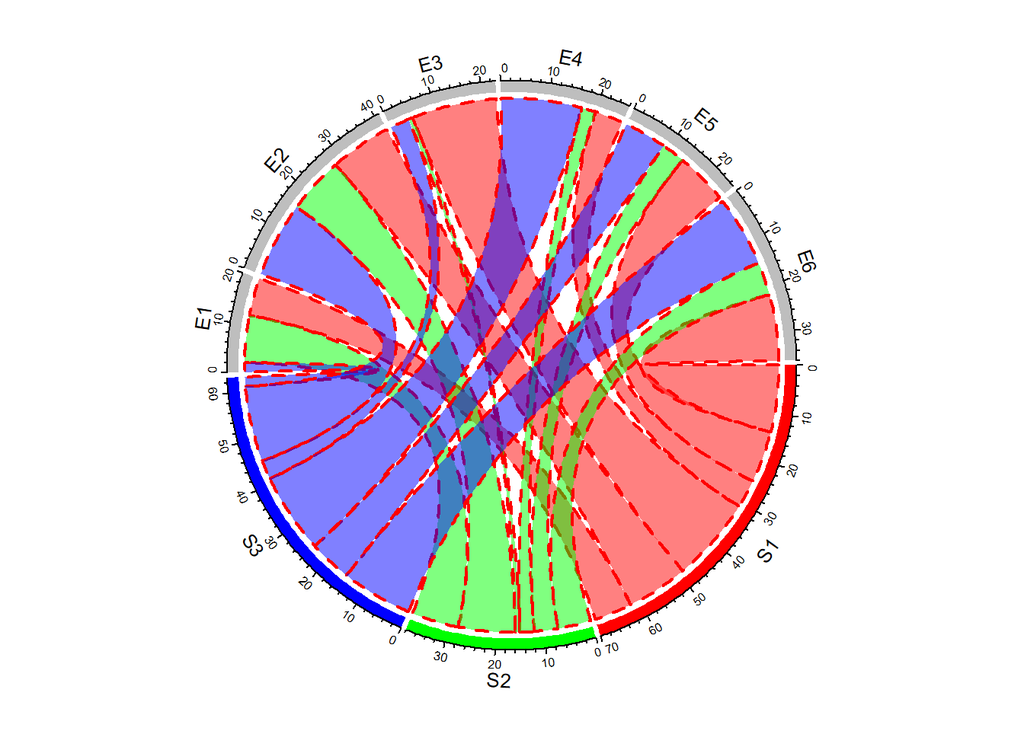

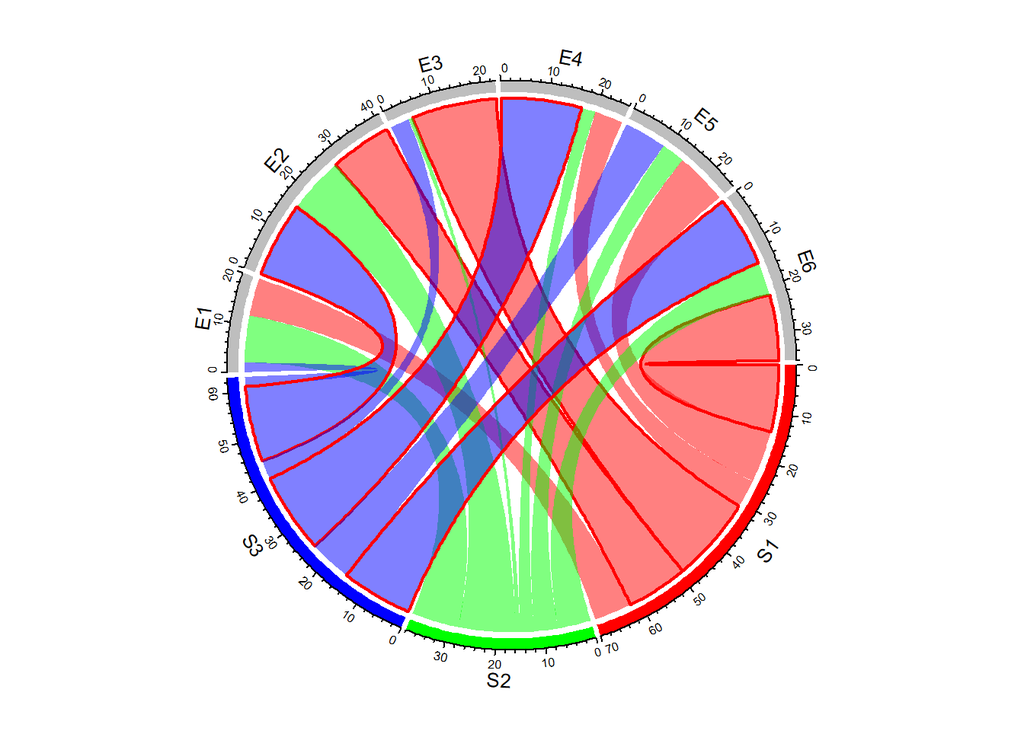

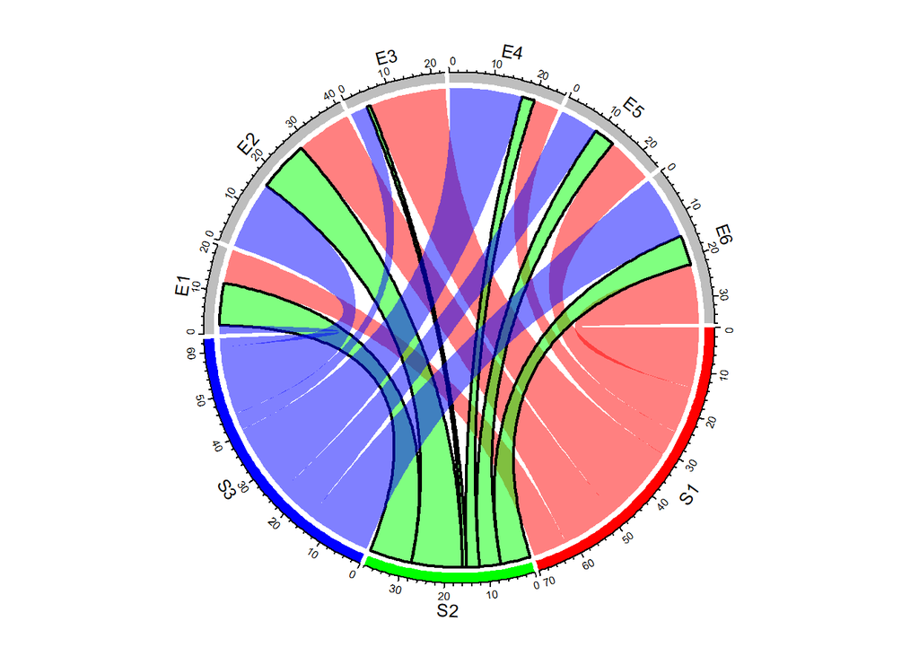

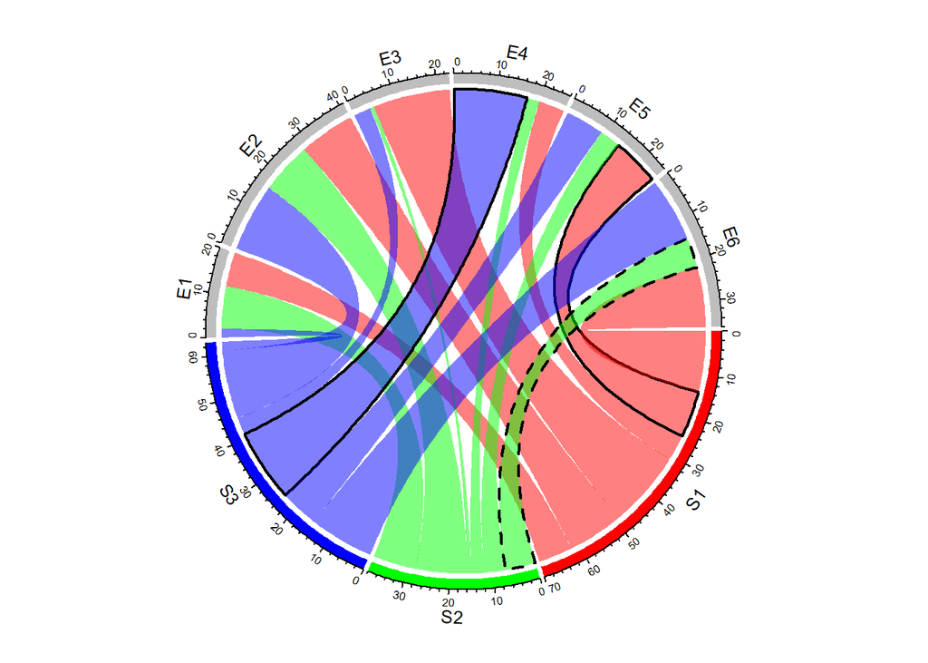

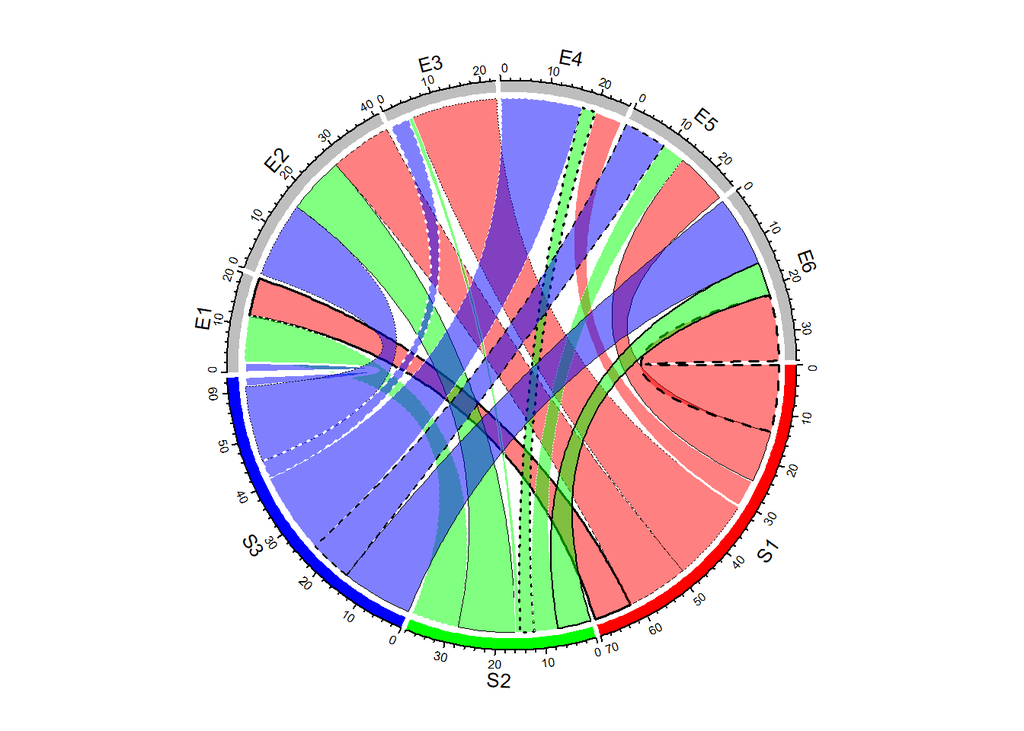

```r
library(circlize)

# 用长度的1的向量指定
chordDiagram(mat, grid.col = grid_col, link.lwd = 2, link.lty = 2, link.border = "red")  # 指定link边线宽度，边线线型，边线颜色
circos.clear()

# 用矩阵指定
lwd_mat <- matrix(1, nrow = nrow(mat), ncol = ncol(mat))  # 元素为1的矩阵，其维度与源数据mat一致
lwd_mat[mat > 12] <- 2  # relation > 12,则加宽link边线
border_mat <- matrix(NA, nrow = nrow(mat), ncol = ncol(mat))  # 元素为NA的矩阵，其维度与源数据mat一致
border_mat[mat > 12] <- "red"  # relation > 2，则为红色边缘线
chordDiagram(mat, grid.col = grid_col, link.lwd = lwd_mat, link.border = border_mat)  # 指定link边缘线宽度，边缘线颜色
circos.clear()

# 参数矩阵维度与数据源不一致,则改变部分颜色,必须按名称属性匹配
border_mat2 <- matrix("black", nrow = 1, ncol = ncol(mat))  # 生成1行的矩阵，其宽与数据源mat一致
rownames(border_mat2) <- rownames(mat)[2]  # 将mat第2个行名赋值给border_mat2，则只会改变第mat第2行的边缘线颜色
colnames(border_mat2) <- colnames(mat)  # 赋值列名，与数据源mat一致
chordDiagram(mat, grid.col = grid_col, link.lwd = 2, link.border = border_mat2)  #
circos.clear()

# 参数矩阵还可以设置为特殊的3列格式，前2列分别对应数据源的行名称和列名称，第3列为参数列，相当于邻接列表格式的参数矩阵
lty_df <- data.frame(c("S1", "S2", "S3"), c("E5", "E6", "E6"), c(1, 2, 3))  # link边缘线分别为1, 2, 3
lwd_df <- data.frame(c("S1", "S2", "S3"), c("E5", "E6", "E4"), c(2, 2, 2))  # link边线线宽为2
border_df <- data.frame(c("S1", "S2", "S3"), c("E5", "E6", "E4"), c(1, 1, 1))  # link边缘线颜色为1
chordDiagram(mat, grid.col = grid_col, link.lty = lty_df, link.lwd = lwd_df,
    link.border = border_df)
circos.clear()

# 当数据源是邻接列表时，只需要指定跟源数据一样行数的向量，特别方便
chordDiagram(df, grid.col = grid_col, link.lty = sample(1:3, nrow(df), replace = TRUE),
    link.lwd = runif(nrow(df)) * 2, link.border = sample(0:1, nrow(df), replace = TRUE))
circos.clear()
```

### 3.2.5 link弦可见

在需要强调某些relation时，需要高亮对应的弦，一般有4种高亮方式：  
* 设置弦边缘颜色(前面已经介绍了)，  
* 设置不同的透明度，  
* 或只显示某些弦，其它全是透明的灰色  
* 通过`link.visible`参数指定要显示的弦，其它都不显示，可以用逻辑矩阵(对于邻接矩阵)或逻辑向量(对于邻接列表)进行指定

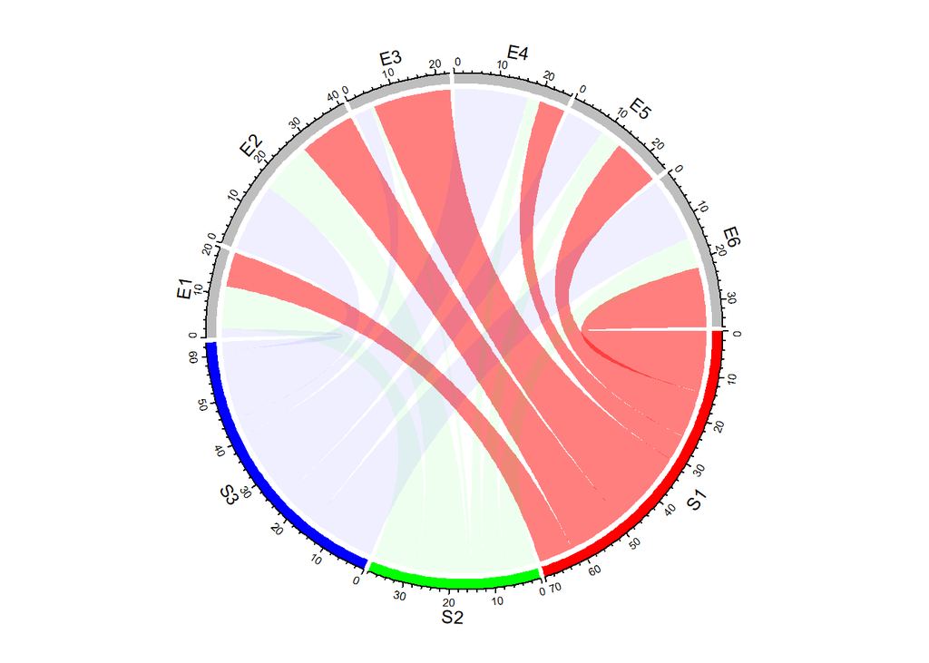

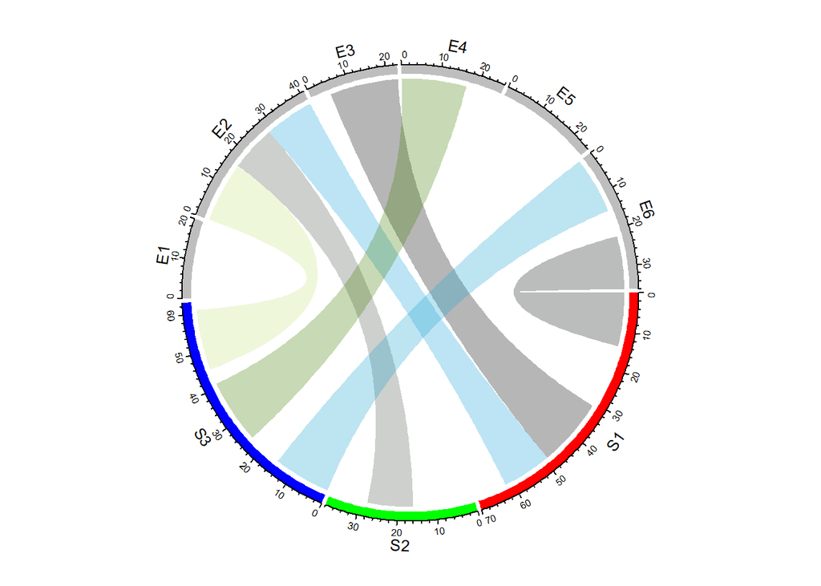

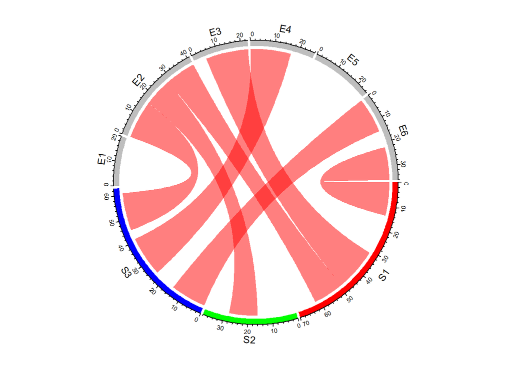

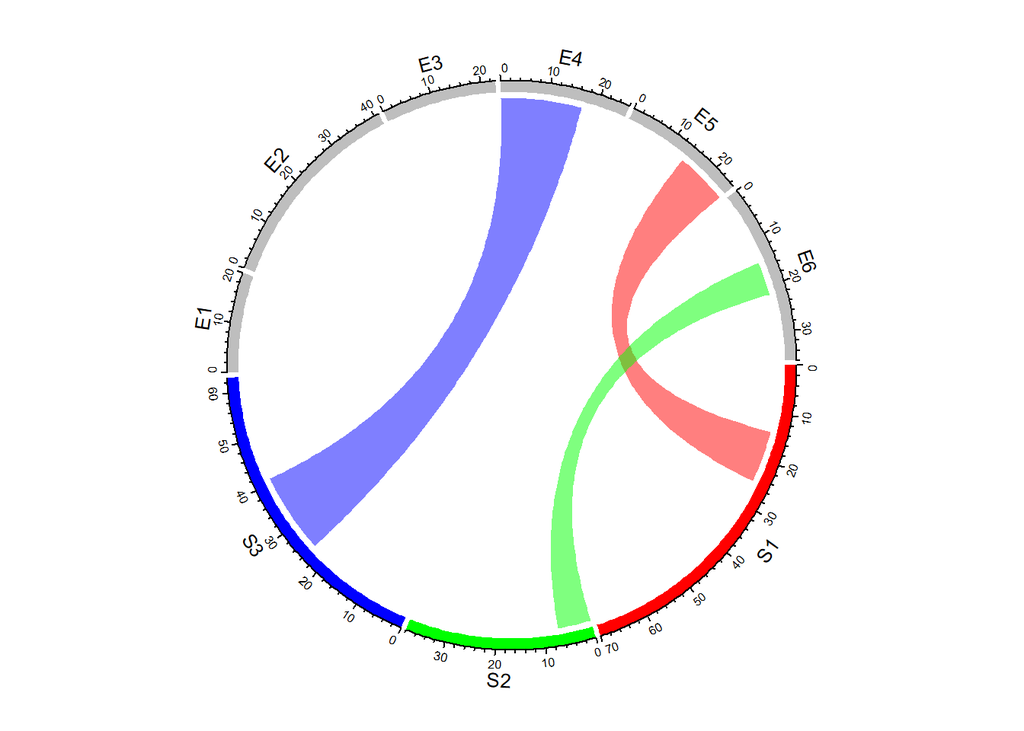

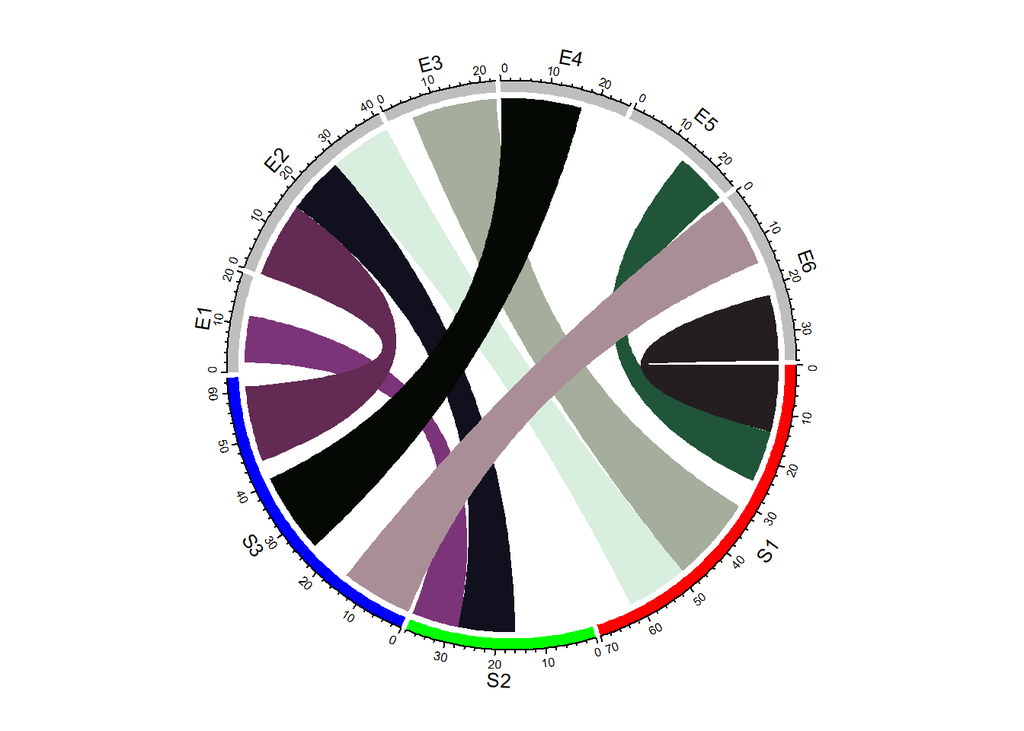

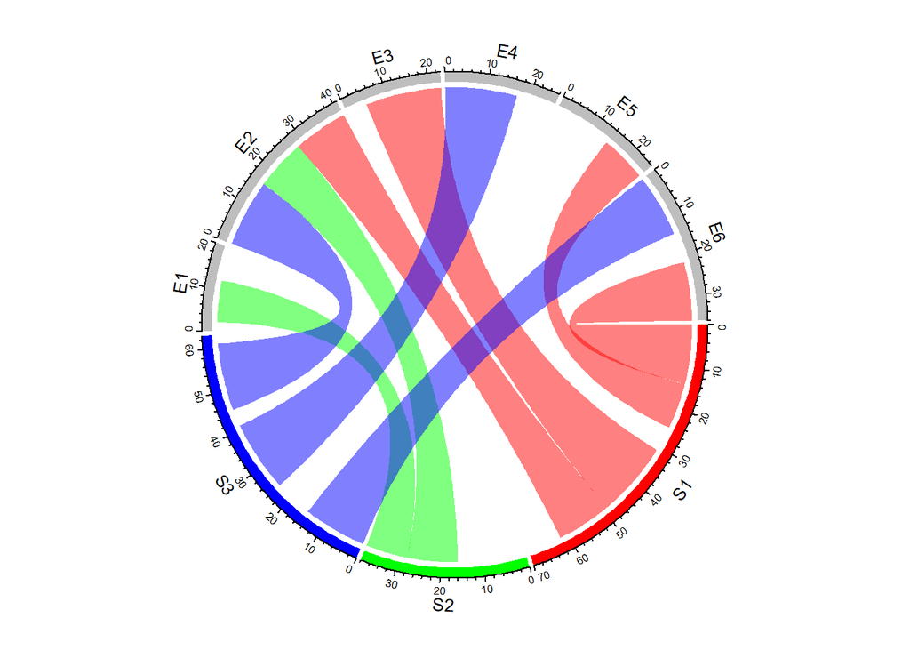

```r
library(circlize)

# 通过指定不同的颜色进行高亮
chordDiagram(mat, grid.col = grid_col, row.col = c("#FF000080", "#00FF0010",
    "#0000FF10"))
circos.clear()

# 通过指定透明色给某些在范围之外的relation
col_mat[mat < 12] <- "#00000000"  # relation < 12则变为透明色
chordDiagram(mat, grid.col = grid_col, col = col_mat)  #
circos.clear()

# 通过函数同时指定透明色和高亮色，对邻接列表数据源也适用
col_fun <- function(x) {
    ifelse(x < 12, "#00000000", "#FF000080")
}  # relation小于12则为透明色，反之为#FF000080石榴红
chordDiagram(mat, grid.col = grid_col, col = col_fun, transparency = 0.7)
circos.clear()

# 事实上，所有颜色矩阵或颜色生成函数中色彩都是绘制在图形中的，只是程序内部将其透明度设置为了1，
# 通过3列特殊数据框指定的颜色，其缺失的颜色的relation将不会画出
col_df <- data.frame(c("S1", "S2", "S3"), c("E5", "E6", "E4"), c("#FF000080",
    "#00FF0080", "#0000FF80"))
chordDiagram(mat, grid.col = grid_col, col = col_df)
circos.clear()

# 对于邻接列表数据源，高亮弦调整更简单，只需要设置要高亮的颜色，其它为透明色就行了
cols <- rand_color(nrow(df))
cols[df[[3]] < 10] <- "#00000000"  # 将df中第3列，即relation列，列值小于10的都更新为透明色HEX色值
chordDiagram(df, grid.col = grid_col, col = cols)

# 通过link.visible参数调整
cols <- rand_color(nrow(df))
chordDiagram(df, grid.col = grid_col, link.visible = df[[3]] >= 10)  # 只显示df第3列大于10的弦
circos.clear()
```

### 3.2.6 弦在同一个sector上的顺序调整

有时候为了方便查询，需要将弦link按宽窄顺序排列，可以用参数`link.sort`和`link.decreasing`设定:  
* `link.sort = TRUE` 表示设置顺序，默认为了好看自动调整弦的顺序,指定该参数后，`link.decreasing` 参数才有效  
* `link.decreasing = TRUE/FALSE` 表示降序或升序，默认顺时针，降序表示宽度沿顺时针方向逐渐下降

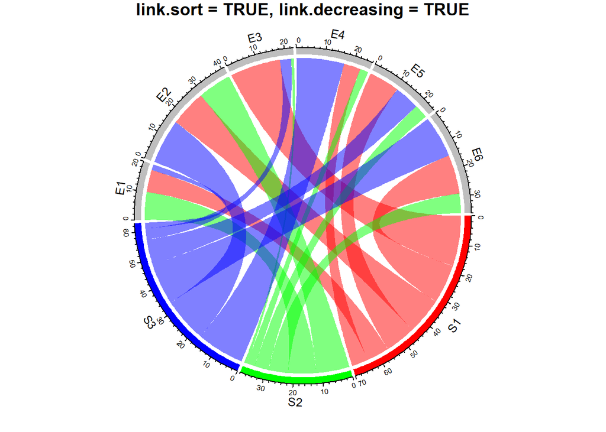

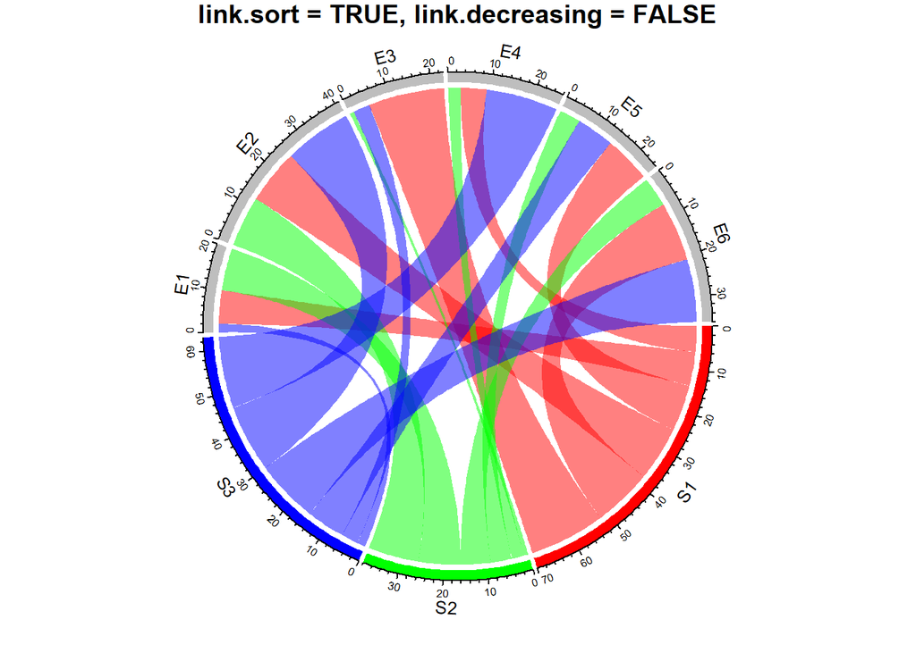

```r
library(circlize)

chordDiagram(mat, grid.col = grid_col, link.sort = TRUE, link.decreasing = TRUE)  #按弦宽度下降排列,则弦宽沿顺时针方向逐渐下降
title("link.sort = TRUE, link.decreasing = TRUE", cex = 0.8)  # 添加标题
circos.clear()

chordDiagram(mat, grid.col = grid_col, link.sort = TRUE, link.decreasing = FALSE)  # 弦宽沿顺时针方向逐渐增大
title("link.sort = TRUE, link.decreasing = FALSE", cex = 0.8)
circos.clear()
```

### 3.2.7 弦在多个sectors上的顺序调整

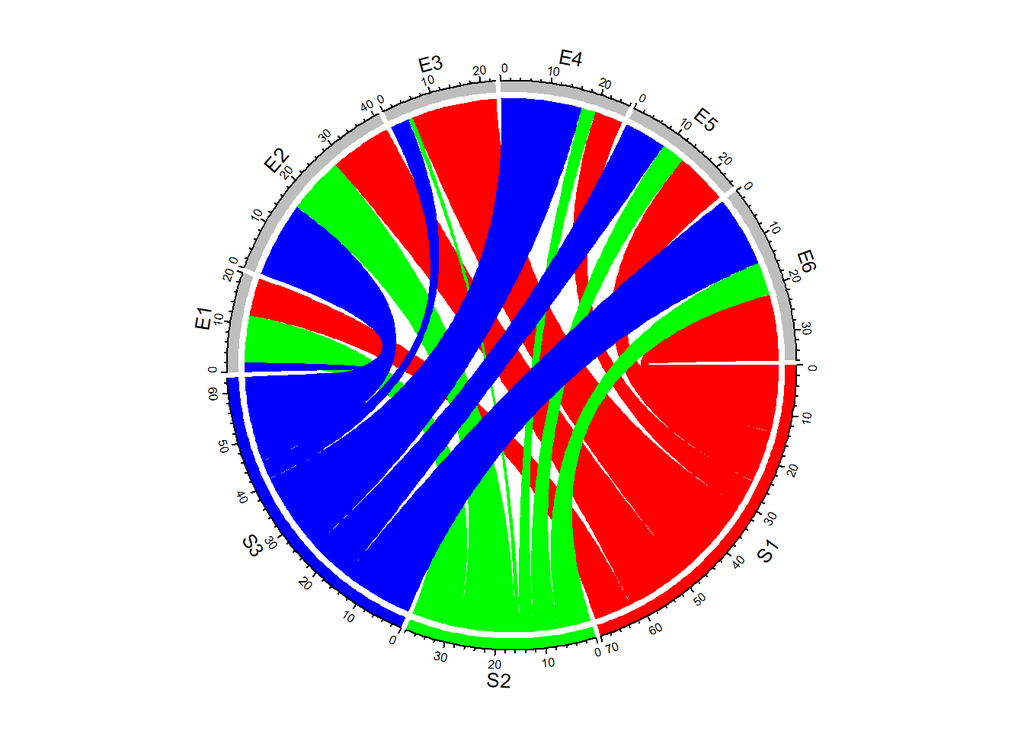

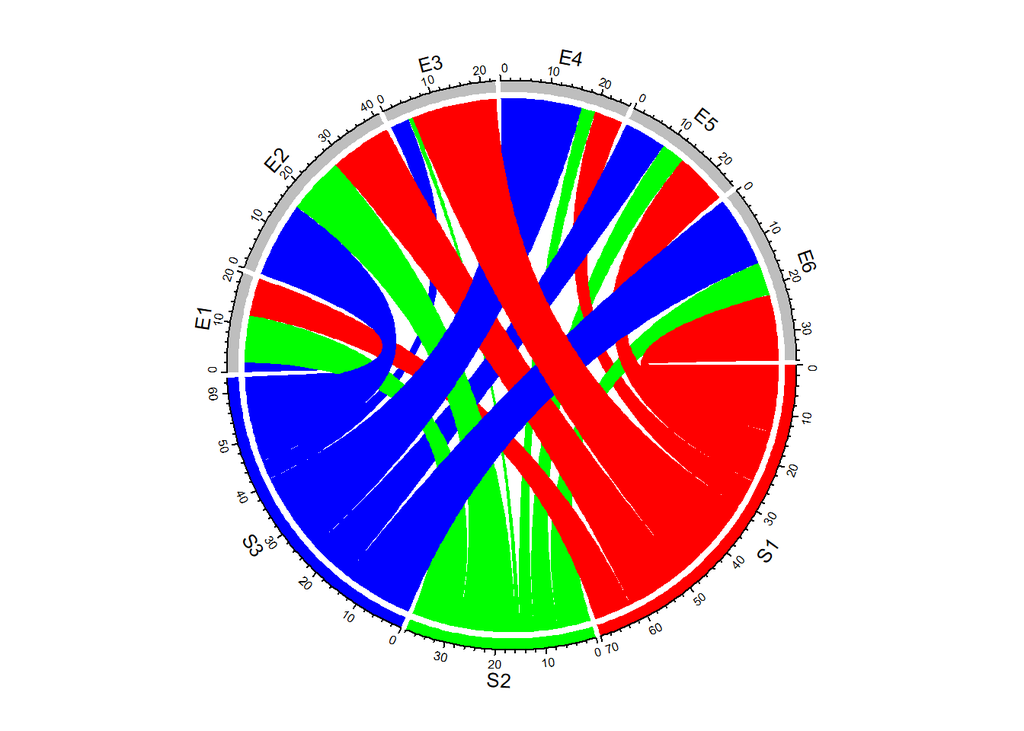

```r
library(circlize)

# 邻接矩阵数据源，求矩阵的秩，然后指定给link.rank参数
chordDiagram(mat, grid.col = grid_col, transparency = 0, link.rank = )  # 设置透明度为0，方便观察
chordDiagram(mat, grid.col = grid_col, transparency = 0, link.rank = rank(mat))  # 用mat中的秩进行排序，秩最大先添加
circos.clear()

# 邻接列表数据源，对relation列求秩，然后指定给link.rank参数
chordDiagram(df, grid.col = grid_col, transparency = 0, link.rank = rank(df[[3]]))  # 第3列为relation列，求秩
circos.clear()
```

[output not shown]

### 3.2.8 自我连接

当信息需要复制的时候，可以使用自我连接，使用参数`self.link`指定，用1或2指定，分别代表2种情形  
这个用在基因或细胞复制的可视化中，其它用的比较少

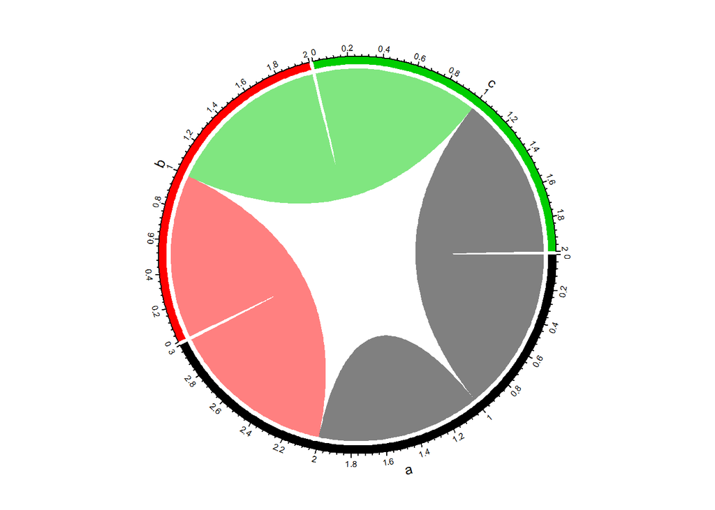

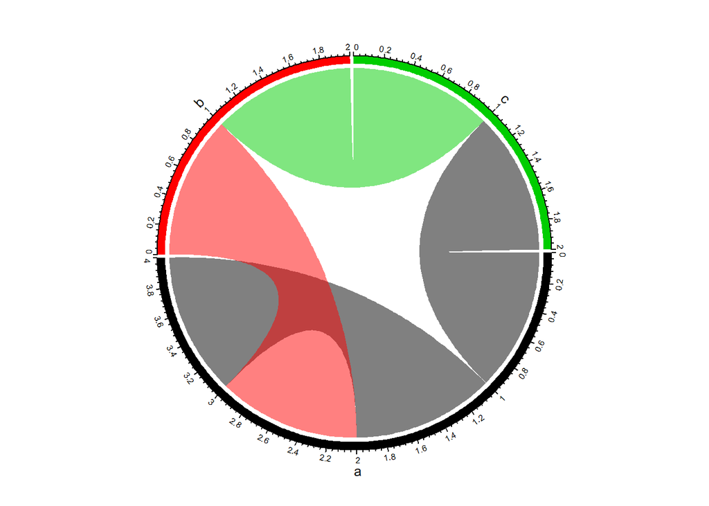

```r
library(circlize)

df2 <- data.frame(start = c("a", "b", "c", "a"), end = c("a", "a", "b", "c"))
chordDiagram(df2, grid.col = 1:3, self.link = 1)  #
chordDiagram(df2, grid.col = 1:3, self.link = 2)
circos.clear()
```

### 3.2.9 对称矩阵

当数据源是对称矩阵时，通过参数`symmetric = TRUE`，只有矩阵下三角部分relation会被可视化(不包括对角线)

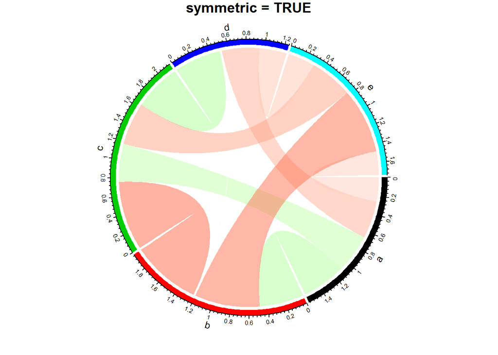

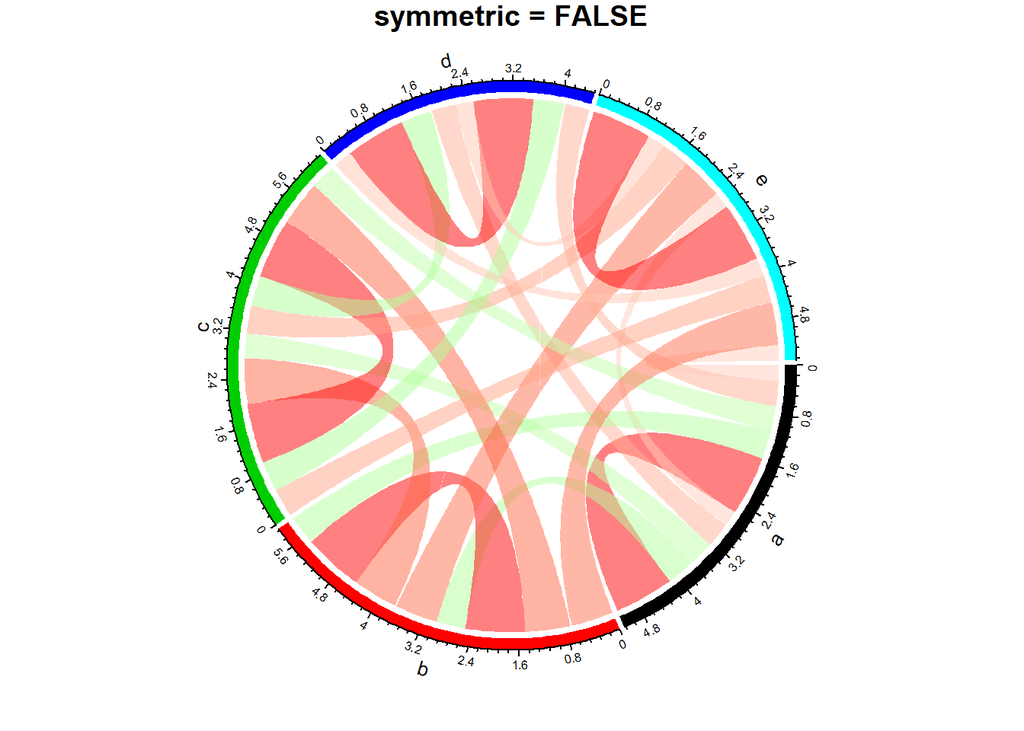

```r
library(circlize)

mat3 <- matrix(rnorm(25), 5)  # 生成25个均匀分布的随机数, 5行排列
colnames(mat3) <- letters[1:5]
cor_mat <- cor(mat3)  # 求相关系数,则变为对称矩阵

col_fun <- colorRamp2(c(-1, 0, 1), c("green", "white", "red"))
chordDiagram(cor_mat, grid.col = 1:5, symmetric = TRUE, col = col_fun)
title("symmetric = TRUE")  # 增加标题
circos.clear()

chordDiagram(cor_mat, grid.col = 1:5, col = col_fun)
title("symmetric = FALSE")
circos.clear()
```